# Anti-aliasing filtering before sampling (Python)

**Goal.** Show (with a concrete, reproducible example) why an *analog* anti‑aliasing filter is needed **before** sampling when out‑of‑band energy can **alias** into the band you care about.

We will:

1. Build a **desired multitone** around a center frequency $f_{c1}$ (below Nyquist).
2. Build a **strong interferer multitone** around $f_{c2}$ (above Nyquist).
3. Apply an **amplitude‑only Butterworth** anti‑aliasing model, then compute **SIDR vs filter order $P$**.
4. Add a simple *worst‑case* **phase distortion** on the desired tones and repeat.

> Key idea: if $f_s=40\,\text{MHz}$, Nyquist is $20\,\text{MHz}$.  
> A tone at $f$ above Nyquist aliases to $|f_s - f|$ (for $f\in(20,40)$ MHz).  
> We intentionally place the interferer so it aliases **close to the desired band**.

```python
import numpy as np
import matplotlib.pyplot as plt
from scipy.signal.windows import blackmanharris

# plotting defaults
plt.rcParams["figure.figsize"] = (9, 4)
plt.rcParams["axes.grid"] = True
```

## 1) Signal model

We model an analog signal

$$ x_a(t) = A_1\,x_{a1}(t) + A_2\,x_{a2}(t) $$

- $x_{a1}(t)$: **desired** component (below Nyquist)
- $x_{a2}(t)$: **interferer** component (above Nyquist)

Each component is a small **cluster of tones**:

$$ x_{ai}(t)=\sum_{k=-K}^{K} \sin\big(2\pi f_{ik} t\big),\quad i\in\{1,2\}. $$

Tone frequencies (a simple symmetric spacing around each center frequency):

$$ f_{1k} = f_{c1} + k\,\Delta f,\qquad f_{2k} = f_{c2} + k\,\Delta f. $$

We sample with:

$$ t_n = \frac{n}{f_s},\quad n=0,1,\dots,N-1. $$

```python
# -------------------------
# Parameters
# -------------------------
fs = 40e6          # sampling frequency (Hz)
N  = 8192          # number of samples
n  = np.arange(N)

P_vec = np.arange(1, 51)   # filter orders to sweep

# Multitone structure (k = -K..K)
K     = 4
Delta = 1/8

# Butterworth cutoff used in the filter model:
# wc = 0.8125*pi*fs  ->  fc_cut = wc/(2*pi) = 0.40625*fs
fc_cut = 0.40625 * fs

# Desired center chosen so the highest desired tone is near the cutoff
fc1 = fc_cut / (1 + K*Delta)
delta_f = fc1 * Delta      # tone spacing in Hz

# Interferer center above Nyquist so it aliases close to the desired band
f_alias_target = fc1 - 0.3e6
fc2 = fs - f_alias_target

A2 = 1.0           # interferer amplitude
```

### Why these frequencies?

Why these numbers? With $f_s=40$ MHz, Nyquist is 20 MHz. We place the interferer above Nyquist (here $f_{c2}\approx 29.47$ MHz) so it **aliases** to $f_s-f_{c2}\approx 10.53$ MHz — right into the desired band near $f_{c1}\approx 10.83$ MHz.

Also, we choose the desired tone spacing so that the **highest desired tone** lands exactly at the filter cutoff $f_c = 0.40625\,f_s = 16.25$ MHz. That creates a fixed passband attenuation on one desired tone and gives a realistic **SIDR saturation** (an error floor) as filter order increases.

## 2) Anti‑aliasing filter model (Butterworth magnitude)

We first ignore phase and model only the **magnitude response**:

$$ |H(j\omega)| = \sqrt{\frac{1}{1 + \varepsilon^2\,(\omega/\omega_c)^{2P}}}. $$

Parameters:

- $P$: Butterworth order (higher $P$ = steeper roll‑off)
- $A_{\max}$: passband ripple constraint in dB
- $\omega_c = 0.8125\,\pi f_s$
- $\varepsilon = \sqrt{10^{0.1A_{\max}} - 1}$

We apply filtering **tone‑by‑tone** by multiplying each sinusoid by $|H(j\omega)|$ at its frequency.

```python
def butterworth_mag(Amax_db, P, omega, fs):
    """Butterworth magnitude response |H(jω)| evaluated at radian freq omega."""
    wc  = 0.8125 * np.pi * fs
    eps = np.sqrt(10**(0.1 * Amax_db) - 1.0)
    return np.sqrt(1.0 / (1.0 + (eps**2) * (omega / wc)**(2*P)))

def multitone_freqs(fc, delta_f, K):
    """Frequencies fc + k*delta_f for k = -K..K."""
    k = np.arange(-K, K+1)
    f = fc + k * delta_f
    return f, k

def multitone_time_signal(freqs, k_index, n, fs, phase_dt=0.0, phase_dist=False):
    """Sum of sinusoids at `freqs` (Hz) sampled at indices n with optional alternating phase."""
    x = np.zeros_like(n, dtype=float)
    for fk, kk in zip(freqs, k_index):
        omega = 2*np.pi*fk
        phi = phase_dt * ((-1.0)**kk) if phase_dist else 0.0  # float base works for negative kk
        x += np.sin(omega * n / fs + phi)
    return x

def filtered_multitone(freqs, k_index, n, fs, Amax_db, P, phase_dt=0.0, phase_dist=False):
    """Apply amplitude-only Butterworth attenuation tone-by-tone, optional phase on desired tones."""
    y = np.zeros_like(n, dtype=float)
    for fk, kk in zip(freqs, k_index):
        omega = 2*np.pi*fk
        H = butterworth_mag(Amax_db, P, omega, fs)
        phi = phase_dt * ((-1.0)**kk) if phase_dist else 0.0
        y += H * np.sin(omega * n / fs + phi)
    return y

def sidr(x, x0):
    """Signal-to-interference-and-distortion ratio in dB."""
    num = np.sum(x0**2)
    den = np.sum((x - x0)**2)
    return 10*np.log10(num / (den + 1e-30))
```

## 3) Metric: SIDR

We quantify how close the sampled signal is to the *ideal desired* component using:

$$ \mathrm{SIDR} = 10\log_{10}\frac{\sum_{n=0}^{N-1} x_0^2[n]}{\sum_{n=0}^{N-1}\big(x[n]-x_0[n]\big)^2}. $$

- $x[n]$: sampled signal after filtering, containing desired + residual interferer
- $x_0[n]$: **reference desired** sequence (desired component only)

Higher SIDR is better.

```python
def sidr(x, x0):
    num = np.sum(x0**2)
    den = np.sum((x - x0)**2)
    return 10*np.log10(num / (den + 1e-30))
```

## 4) Experiment A: SIDR vs filter order $P$ (magnitude‑only)

We sweep:

$$ P = 1,2,\dots,P_{\max} $$

for four parameter combinations:

- $A_1 \in \{1,\;0.01\}$ (desired strength)
- $A_{\max} \in \{0.1,\;0.01\}\,\text{dB}$ (passband ripple constraint)

with fixed $A_2=1$.

**What you should expect**

- Increasing $P$ should **improve** SIDR at first (better stopband attenuation).
- SIDR eventually **saturates** (limited by how we define the reference, and by the filter passband behavior).
- Smaller $A_1$ makes the problem harder (desired is weaker).

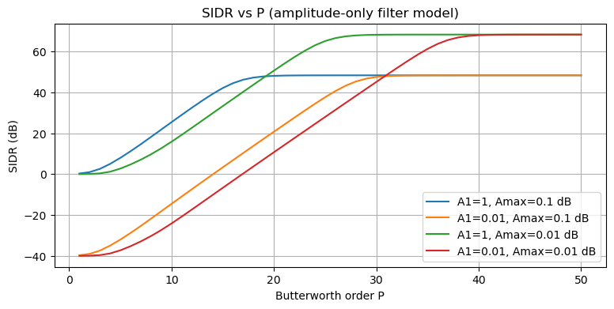

```python
def sidr_vs_P(A1, Amax_db, n, fs, fc1, fc2, delta_f, K, A2, P_vec, phase_dt=0.0, include_phase_dist=False):
    """Compute SIDR(P) for one configuration."""
    f1, k1 = multitone_freqs(fc1, delta_f, K)
    f2, k2 = multitone_freqs(fc2, delta_f, K)

    # Reference desired (unfiltered desired only)
    x1 = multitone_time_signal(f1, k1, n, fs, phase_dt=phase_dt, phase_dist=include_phase_dist)
    x0 = A1 * x1

    out = []
    for P in P_vec:
        y1 = filtered_multitone(f1, k1, n, fs, Amax_db, P, phase_dt=phase_dt, phase_dist=include_phase_dist)
        y2 = filtered_multitone(f2, k2, n, fs, Amax_db, P, phase_dt=0.0,      phase_dist=False)
        y = A1*y1 + A2*y2
        out.append(sidr(y, x0))
    return np.array(out)

cases = [
    (1.0,   0.1),
    (0.01,  0.1),
    (1.0,   0.01),
    (0.01,  0.01),
]

fig, ax = plt.subplots(figsize=(9, 4))
for A1, Amax_db in cases:
    ax.plot(P_vec, sidr_vs_P(A1, Amax_db, n, fs, fc1, fc2, delta_f, K, A2, P_vec),
            label=f"A1={A1:g}, Amax={Amax_db:g} dB")

ax.set_xlabel("Butterworth order P")
ax.set_ylabel("SIDR (dB)")
ax.set_title("SIDR vs P (amplitude-only filter model)")
ax.legend()
plt.show()
```

Note. At low filter orders, SIDR is dominated by the relative power of the desired and interfering signals; when the desired signal is weaker (e.g., $A_1 \ll A_2$), the SIDR therefore starts at a negative value corresponding to the initial power ratio.

## 5) FFT evidence (what is aliasing doing?)

SIDR is a single number. To **see** what happens, we also look at the spectrum of the sampled sequence.

We compute a windowed FFT:

$$ X[k] = \sum_{n=0}^{N-1} x[n]\,w[n] e^{-j 2\pi k n/N}. $$

and plot the normalized magnitude in dB:

$$ A[k] = 20\log_{10}\left(\frac{|X[k]|}{\max_k |X[k]|}\right). $$

We use a Blackman–Harris window to reduce spectral leakage so the tone clusters are easier to interpret.

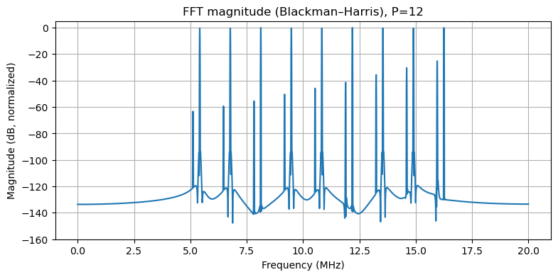

```python
# Pick a representative P (change to explore)
P_demo = 12
A1_demo, A2_demo = 1.0, 1.0
Amax_demo = 0.1

f1, k1 = multitone_freqs(fc1, delta_f, K)
f2, k2 = multitone_freqs(fc2, delta_f, K)

y1 = filtered_multitone(f1, k1, n, fs, Amax_demo, P_demo)
y2 = filtered_multitone(f2, k2, n, fs, Amax_demo, P_demo)
y  = A1_demo*y1 + A2_demo*y2

w = blackmanharris(N)
Y = np.fft.fft(y * w)

A_db = 20*np.log10(np.maximum(np.abs(Y), 1e-20) / np.max(np.abs(Y)))

freq = np.fft.fftfreq(N, d=1/fs)

fig, ax = plt.subplots(figsize=(9, 4))
ax.plot(freq[:N//2] * 1e-6, A_db[:N//2])
ax.set_xlabel("Frequency (MHz)")
ax.set_ylabel("Magnitude (dB, normalized)")
ax.set_title(f"FFT magnitude (Blackman–Harris), P={P_demo}")
ax.set_ylim(-160, 5)
plt.show()
```

## 6) Experiment B: add phase distortion on desired tones

Amplitude suppression is not the whole story: real filters can also introduce phase distortion.

We add a simple alternating phase error on the **desired** tones:

$$ \phi_k = \Delta\,(-1)^k $$

and repeat SIDR vs $P$ for $\Delta\in\{0.1,\;0.01\}$ radians.

(We keep the interferer phase at 0 because, ideally, it should be heavily attenuated anyway.)

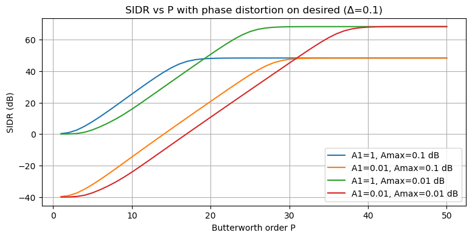

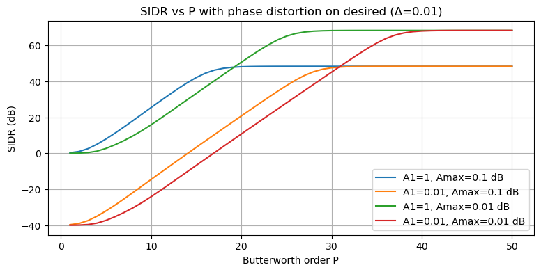

```python
for dt in [0.1, 0.01]:
    fig, ax = plt.subplots(figsize=(9, 4))
    for A1, Amax_db in cases:
        s = sidr_vs_P(A1, Amax_db, n, fs, fc1, fc2, delta_f, K, A2, P_vec,
                      phase_dt=dt, include_phase_dist=True)
        ax.plot(P_vec, s, label=f"A1={A1:g}, Amax={Amax_db:g} dB")

    ax.set_xlabel("Butterworth order P")
    ax.set_ylabel("SIDR (dB)")
    ax.set_title(f"SIDR vs P with phase distortion on desired (Δ={dt})")
    ax.legend()
    plt.show()
```

## 7) What to try next

If you want to explore:

- Move the interferer center $f_{c2}$ closer to Nyquist (or closer to $f_s$) and see how the alias moves.
- Increase/decrease cluster width (change $K$ or $\Delta f$).
- Try a different $f_s$ and check how the alias location changes.

## Disclaimer

This tutorial contains **original Python implementations** and is intended for **educational** use. It demonstrates generally known signal‑processing concepts (aliasing, filtering, and spectral analysis).